First, we want to add the tidyverse library and read in the Airbnb data for New York, New York.

```r
library(gapminder)
```

```r
library(tidyverse)
library(ggplot2)
library(broom)
data = read_csv('listings.csv')
data
```

```
## # A tibble: 49,056 x 16
##       id name  host_id host_name neighbourhood_g~ neighbourhood latitude
##    <dbl> <chr>   <dbl> <chr>     <chr>            <chr>            <dbl>
##  1  2515 Stay~    2758 Steph     Manhattan        Harlem            40.8
##  2 21456 Ligh~   42032 Dana      Manhattan        Upper West S~     40.8
##  3  2539 Clea~    2787 John      Brooklyn         Kensington        40.6
##  4 21644 Uppe~   82685 Elliott   Manhattan        Harlem            40.8
##  5  2595 Skyl~    2845 Jennifer  Manhattan        Midtown           40.8
##  6 21794 COZY~   83257 Olan      Manhattan        Chelsea           40.7
##  7 22911 The ~   87773 Shelly    Brooklyn         Bedford-Stuy~     40.7
##  8  3330 ++ B~    4177 Jbee      Brooklyn         Williamsburg      40.7
##  9 22918 loft~   32294 Ssameer ~ Manhattan        Harlem            40.8
## 10  3647 THE ~    4632 Elisabeth Manhattan        Harlem            40.8
## # ... with 49,046 more rows, and 9 more variables: longitude <dbl>,
## #   room_type <chr>, price <dbl>, minimum_nights <dbl>,
## #   number_of_reviews <dbl>, last_review <date>, reviews_per_month <dbl>,
## #   calculated_host_listings_count <dbl>, availability_365 <dbl>
```

We want to answer a couple of questions using the Airbnb data. Recently, there was a report that 72% of Airbnb listings in New York city are illegal (https://www.wired.com/2014/10/report-says-72-percent-airbnbs-new-york-rentals-illegal/). In New York, you aren’t allowed to rent an entire apartment/house for less than 30 days, unless the tenants are also living in the home. We want to test this claim by finding out the total number of listings in New York City, then find out how many of those listings are “Entire home/apt” listings with a minimum number of nights that is less than 30.

In this process of the pipeline, we are currating our data to the requirements that we just stated, then we use the function “nrow” to return the number of rows in the database, corresponding to the number of listings.

```r
data<-data%>%
  filter(price < 500)
total_num_listings<- nrow(data)
total_num_listings
```

```
## [1] 47813
```

```r
illegal_units<-data %>%
  filter(room_type == 'Entire home/apt')%>%
  filter(minimum_nights < 30)
num_illegal_units<-nrow(illegal_units)
num_illegal_units
```

```
## [1] 21636
```

```r
percentage<- num_illegal_units/total_num_listings
percentage
```

```
## [1] 0.4525129
```

We can clearly see that the report is a bit off in the calculation of the 72% of listings. Although we don’t know exactly how they got to this percentage, it seems unlikely that 72% of listings are illegal. On the other hand, 45% is still a very high number of listings that are illegal according to New York State Law.

Another question I wanted to answer is, do listings with more reviews(and hence, more stays) generate a higher priced listing? Can a tenant make more money by being a better host and hosting more people? if not, what factors go into determining the price of a listing?

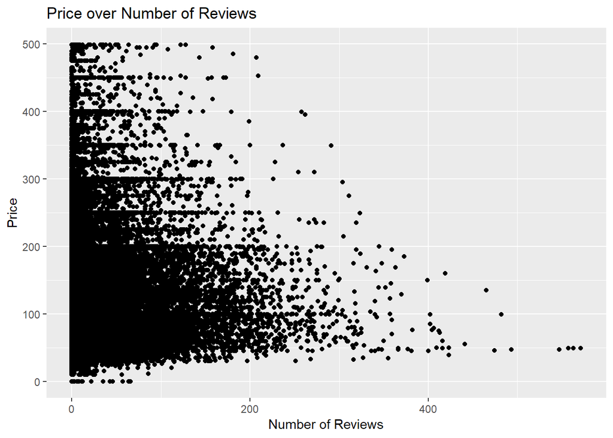

```r
data%>%
  ggplot(mapping = aes(x=number_of_reviews, y = price)) +
  geom_point() +
  labs(title="Price over Number of Reviews",
         x = "Number of Reviews",
         y = "Price")
```

Based on this plot, it seems unlikely that the number of reviews has a direct correlation with price. Perhaps it could have an inverse correlation, but the graph seems to exponential for that to be true as well. We will run a linear regression model on this to see if there is a correlation between price and number of reviews. We will use the “lm” function in R to create a linear regression model. The goal of this is to determine the role that one attribute plays on another attribute, in our case, the role of the number of reviews on price. to Learn more about the “lm” function, take a look at this page: https://www.r-bloggers.com/r-tutorial-series-simple-linear-regression/

```r
model <- lm(price~number_of_reviews, data= data)


model%>%
  tidy()
```

```
## # A tibble: 2 x 5
##   term               estimate std.error statistic    p.value
##   <chr>                 <dbl>     <dbl>     <dbl>      <dbl>
## 1 (Intercept)        132.       0.442      299.   0
## 2 number_of_reviews   -0.0439   0.00941     -4.67 0.00000307
```

As we can see from the linear regression model. the number of reviews has a p value that is less than the significance level (.05) so it does play a role in determining price, however, the price actually drops by -.043 per review. This could be because the cheaper listings tend to get more reviews because they are more popular.

Now, let’s see how the neighborhood can effect price. Our data set has a value “neighbourhood_group” that we want to use. One issue we need to solve in regards to formatting this data is to convert the “neighbourhood_group” category from char data type to factor so that we can run the linear regression model. Once we have the data formatted correctly, we will run the liner regression model using the “lm” function then we will augment it so that we can create violin plots. These violin plots will tell us whether or not neighbourhood has a significant effect on price. If neighbourhood doesn’t have an effect, the violin shapes should look very similar, but if it does, the violins should look very defferent from each other.

```r
data$neighbourhood_group <- as.factor(data$neighbourhood_group)

neighbourhood_model <- lm(price~neighbourhood_group, data= data)
neighbourhood_model%>%
  tidy()
```

```
## # A tibble: 5 x 5
##   term                             estimate std.error statistic   p.value
##   <chr>                               <dbl>     <dbl>     <dbl>     <dbl>
## 1 (Intercept)                         79.2       2.64     30.0  2.20e-195
## 2 neighbourhood_groupBrooklyn         32.4       2.70     12.0  5.82e- 33
## 3 neighbourhood_groupManhattan        82.4       2.70     30.5  1.36e-202
## 4 neighbourhood_groupQueens           12.0       2.87      4.20 2.64e-  5
## 5 neighbourhood_groupStaten Island     7.90      5.24      1.51 1.31e-  1
```

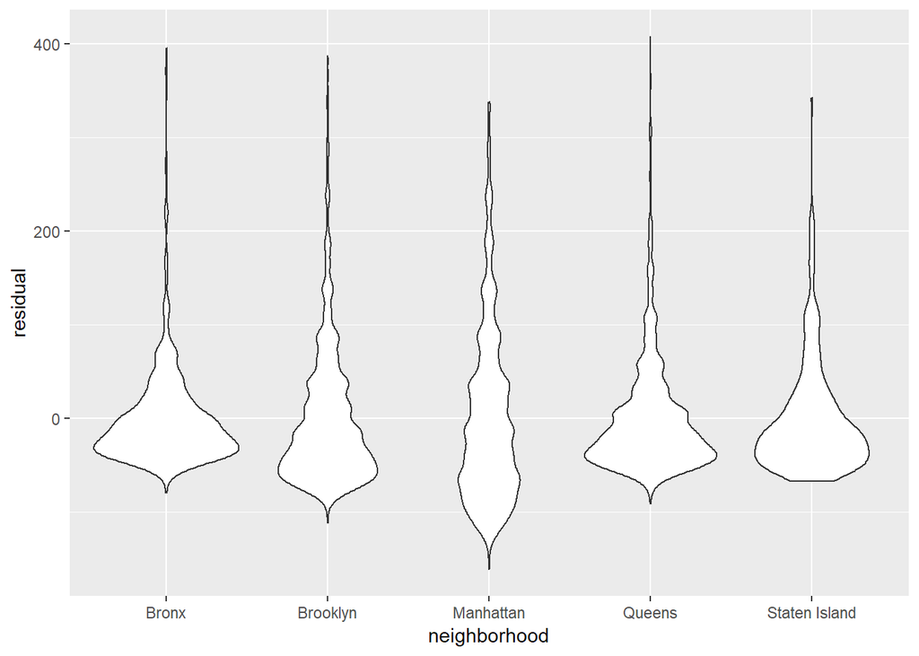

```r
augmented_neighbourhood<- neighbourhood_model%>%
  augment()
augmented_neighbourhood%>%
  ggplot(aes(x=neighbourhood_group,y=.resid)) +
    geom_violin() +
    labs(x="neighborhood", y="residual")
```